# RNA-seq linear modeling

`limma` and `kimma`

Author

Kim Dill-McFarland

Published

November 4, 2024

# RNA-seq linear modeling

## Overview

Here, we introduce some R packages designed for running linear models across many 1000s of genes in an efficient manor.

## Load packages

```r
#Data manipulation and plotting
library(tidyverse)
#Linear modeling
library(kimma)
library(limma)
set.seed(651)
```

## Load data

Data can be downloaded [here](https://github.com/BIGslu/workshops/raw/main/2022.08.15_R.tidyverse.workshop/data/data.zip)

All counts, gene, and sample metadata are contained in a single object.

```r
#Load data
load("data/dat_voom.RData")
```

`dat` object appears in our current R environment.

## Modeling in `limma`

### Simple linear regression in `limma`

`limma` take model inputs as a model matrix instead of the `~ variable` formula format you’ve seen with `lm` and `lmer`. This matrix encodes all the variables from the formula as 0 for N and 1 for Y. For example, here is the model matrix for the formula `~ condition + sex`

```r
mm_limma <- model.matrix(~ condition + sex, data=dat$targets)

head(mm_limma)
```

```
           (Intercept) conditionMtb sexM
pt01_Media           1            0    1
pt01_Mtb             1            1    1
pt02_Media           1            0    1
pt02_Mtb             1            1    1
pt03_Media           1            0    1
pt03_Mtb             1            1    1
```

```r
# Set order of sex variable as factors
dat$targets <- dat$targets %>%
  mutate(sex = factor(sex, levels = c("M","F")))

#Make model matrix
mm_limma <- model.matrix(~ condition + sex, data=dat$targets)

head(mm_limma)
```

```
           (Intercept) conditionMtb sexF
pt01_Media           1            0    0
pt01_Mtb             1            1    0
pt02_Media           1            0    0
pt02_Mtb             1            1    0
pt03_Media           1            0    0
pt03_Mtb             1            1    0
```

Once we have a model matrix, we fit the model and estimate P-values.

```r
#Fit model
fit_limma <- lmFit(object = dat$E, design = mm_limma,
                   weights = dat$weights)
#Estimate significance
efit_limma <- eBayes(fit = fit_limma)
```

These outputs contain a lot of information. We can pull out the most commonly used pieces with `topTable`. By default, this gives your the 10 most significant genes across the entire model.

```r
#Extract results
fdr_limma <- topTable(fit = efit_limma)
```

```
Removing intercept from test coefficients
```

With some additional parameters, we can get all gene results for each variable.

```r
fdr_limma_mtb <- topTable(fit = efit_limma,
                      coef = "conditionMtb", number = Inf)
fdr_limma_sex <- topTable(fit = efit_limma,
                      coef = "sexF", number = Inf)

head(fdr_limma_mtb)
```

```
            logFC  AveExpr        t      P.Value    adj.P.Val        B
PLEKHM3  2.690201 5.973384 15.37621 6.888863e-13 9.244165e-09 19.59613
MAFF     3.276295 6.164289 14.07285 3.769007e-12 2.528815e-08 17.95641
PPP1R15B 1.856514 8.167870 13.37282 9.911130e-12 3.472082e-08 17.02685
CCL3     5.390670 8.467644 13.34214 1.034975e-11 3.472082e-08 16.94657
RABGEF1  1.732223 6.129960 12.94266 1.832223e-11 3.582863e-08 16.44090
IRAK2    4.532959 5.898344 12.93913 1.841603e-11 3.582863e-08 16.36725
```

```r
head(fdr_limma_sex)
```

```
            logFC  AveExpr         t      P.Value    adj.P.Val        B
DDX3Y  -10.860939 4.023600 -67.09595 5.979891e-26 4.012208e-22 39.77376
RPS4Y1  -9.854802 3.295219 -67.41397 5.418008e-26 4.012208e-22 37.39048
KDM5D   -9.253437 2.870455 -58.22743 1.149610e-24 5.142204e-21 34.82432
UTY     -8.891150 2.884104 -40.20886 2.522091e-21 6.768787e-18 32.06835
EIF1AY  -7.837518 1.921431 -49.99166 2.749097e-23 9.222533e-20 29.63353
ZFY     -8.025645 2.634853 -32.79599 1.693467e-19 3.787438e-16 29.10000
```

The variables included are:

- logFC: log fold change. The sign is relative to your reference. For example, negative logFC for conditionMtb means Mtb minus media is negative and thus, expression is lower in Mtb-infected samples.
- AveExpr: average expression across all samples
- t: test statistic for significance
- P.Value
- adj.P.Val: FDR adjusted P-value
- B: beta coefficient

With some tidyverse manipulation, we can get results for all genes and variables in one table. Or you can use the `kimma` function `extract_lmFit` and skip the coding! This also renames the columns to match `kimma`’s output.

```r
fdr_limma <- extract_lmFit(design = mm_limma, fit = efit_limma)

head(fdr_limma)
```

```
$lm
      model            gene variable      estimate         pval          FDR
1     limma           DDX3Y     sexF -1.086094e+01 5.979891e-26 4.012208e-22
2     limma          RPS4Y1     sexF -9.854802e+00 5.418008e-26 4.012208e-22
3     limma           KDM5D     sexF -9.253437e+00 1.149610e-24 5.142204e-21
4     limma             UTY     sexF -8.891150e+00 2.522091e-21 6.768787e-18
5     limma          EIF1AY     sexF -7.837518e+00 2.749097e-23 9.222533e-20
6     limma             ZFY     sexF -8.025645e+00 1.693467e-19 3.787438e-16
7     limma           USP9Y     sexF -7.816763e+00 2.061475e-17 3.951848e-14
8     limma          CD300E     sexF  3.083193e+00 4.338287e-08 7.276934e-05
9     limma           KDM6A     sexF  1.006074e+00 1.931432e-07 2.838687e-04
10    limma             ZFX     sexF  9.153972e-01 2.272135e-07 2.838687e-04
11    limma         C9orf72     sexF  8.719435e-01 2.326966e-07 2.838687e-04
12    limma           PDE4A     sexF  9.888933e-01 7.571416e-07 8.466736e-04
13    limma            CA12     sexF  6.112319e+00 1.176598e-06 1.214520e-03
```

[output cut: 35633 more lines]

### Paired sample design in `limma`

`limma` uses a shortcut to model paired sample designs. Unlike what you saw with `lmer` (which is a true mixed effect model), `limma` estimates the mean correlation of gene expression between pairs. This is an okay approximation of a mixed effects model and runs very fast.

Using the same model as before, we can calculate the mean correlation.

```r
consensus.corr <- duplicateCorrelation(object = dat$E,
                                       design = mm_limma,
                                       block = dat$targets$ptID)
consensus.corr$consensus.correlation
```

```
[1] 0.3925634
```

Note: If you get an error about the package `statmod`, please install this package with `install.packages("statmod")`

Then incorporate this estimate into our model fitting.

```r
# Fit model
fit_limma2 <- lmFit(object = dat$E, design = mm_limma,
                    weights = dat$weights,
                    block = dat$targets$ptID,
                    correlation = consensus.corr$consensus.correlation)
#Estimate p-values
efit_limma2 <- eBayes(fit_limma2)

#Get results
fdr_limma2 <- extract_lmFit(design = mm_limma, fit = efit_limma2)
```

Comparing these results for the condition variable, we see that the pseudo-paired model with duplicateCorrelation tends to give lower FDR values. This doesn’t necessarily mean the model is a better fit!

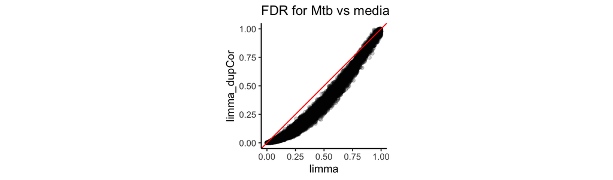

```r
#Format results for merging
temp <- fdr_limma$lm %>%
  select(gene, variable, FDR) %>%
  filter(variable == "conditionMtb") %>%
  rename(`limma` = FDR)

temp2 <- fdr_limma2$lm %>%
  select(gene, variable, FDR) %>%
  filter(variable == "conditionMtb") %>%
  rename(limma_dupCor = FDR)

#Merge results and plot FDR
full_join(temp, temp2) %>%
  ggplot(aes(x = `limma`, y = limma_dupCor)) +
  geom_point(alpha = 0.2) +
  geom_abline(intercept = 0, slope = 1, color = "red") +
  theme_classic() +
  coord_fixed() +
  labs(title = "FDR for Mtb vs media")
```

`limma` provides one fit quality metric, sigma, which is the estimated standard deviation of the errors. Looking at this, we see that the best fit model (lowest sigma) varies from gene to gene. To be honest, however, sigma is not the best way to assess model fit. We’ll next move into `kimma` where we can compare models with more fit metrics as well as run a true paired mixed effects model.

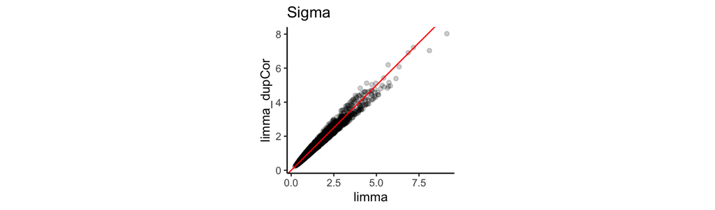

```r
data.frame(`limma` = efit_limma$sigma,
           limma_dupCor = efit_limma2$sigma) %>%

  ggplot(aes(x = `limma`, y = limma_dupCor)) +
  geom_point(alpha = 0.2) +
  geom_abline(intercept = 0, slope = 1, color = "red") +
  theme_classic() +
  coord_fixed() +
  labs(title = "Sigma")
```

## Modeling in `kimma`

`kimma` supports more flexible modeling of RNA-seq data including simple linear and linear mixed effects models with co-variates, weights, random effects, and matrix random effects. Let’s run the same models as we did with `limma`.

Note that `kimma` is much slower than `limma`. It can be run on multiple processors to increase speed but if you don’t have a very powerful laptop, DO NOT RUN the next section of code.

```r
fit_kimma <- kmFit(dat = dat,
                   model = "~ condition + sex + (1|ptID)",
                   use_weights = TRUE,
                   run_lm = TRUE, run_lme = TRUE,
                   metrics = TRUE)

save(fit_kimma, file="data/kimma_result.RData")
```

```
lm model: expression~condition+sex
lme/lmerel model: expression~condition+sex+(1|ptID)
Input: 20 libraries from 10 unique patients
Model: 20 libraries
Complete: 13419 genes
Failed: 0 genes
```

In the interest of time, we’ve provided the `kimma` results for you.

```r
load("data/kimma_result.RData")
```

The `kimma` output contains 4 data frames: one that matches the `limma` output and one with fit metrics for each model.

```r
names(fit_kimma)
```

```
[1] "lm"      "lme"     "lm.fit"  "lme.fit"
```

```r
head(fit_kimma$lm)
```

```
# A tibble: 6 × 8
  model gene  variable        df statistic estimate     pval      FDR
  <chr> <chr> <chr>        <int>     <dbl>    <dbl>    <dbl>    <dbl>
1 lm    A1BG  (Intercept)     17     7.43    1.38   9.83e- 7 1.35e- 6
2 lm    A1BG  conditionMtb    17    -1.12   -0.313  2.79e- 1 4.09e- 1
3 lm    A1BG  sexF            17    -0.236  -0.0796 8.16e- 1 9.39e- 1
4 lm    A2M   (Intercept)     17    25.0     6.79   7.69e-15 1.36e-14
5 lm    A2M   conditionMtb    17    -0.342  -0.127  7.36e- 1 8.15e- 1
6 lm    A2M   sexF            17    -3.33   -1.44   3.96e- 3 8.24e- 2
```

```r
head(fit_kimma$lm.fit)
```

```
# A tibble: 6 × 7
  model  gene   sigma   AIC   BIC    Rsq adj_Rsq
  <chr>  <chr>  <dbl> <dbl> <dbl>  <dbl>   <dbl>
1 lm.fit A1BG   0.766  43.4  47.4 0.0730 -0.0360
2 lm.fit A2M    2.82   54.9  58.9 0.400   0.329
3 lm.fit A2ML1  0.582  58.4  62.4 0.638   0.595
4 lm.fit A4GALT 1.89   80.0  84.0 0.440   0.374
5 lm.fit AAAS   0.971  25.1  29.1 0.335   0.257
6 lm.fit AACS   0.706  15.6  19.6 0.336   0.258
```

We can now look at metrics like AIC where we see that best fit still varies by gene (which is very common) and the overall AIC mean is lower for the simple linear model without paired design.

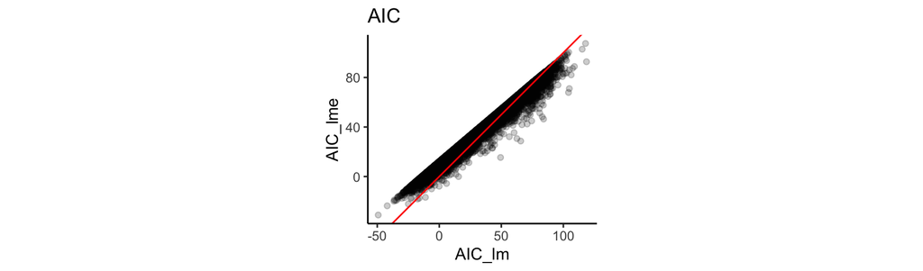

```r
fit_kimma_all <- full_join(fit_kimma$lm.fit, fit_kimma$lme.fit,
          by = c("gene"), suffix = c("_lm","_lme"))

fit_kimma_all %>%
  ggplot(aes(x = AIC_lm, y = AIC_lme)) +
  geom_point(alpha = 0.2) +
  geom_abline(intercept = 0, slope = 1, color = "red") +
  theme_classic() +
  coord_fixed() +
  labs(title = "AIC")
```

```r
mean(fit_kimma$lm.fit$AIC)
```

```
[1] 33.39391
```

```r
mean(fit_kimma$lme.fit$AIC)
```

```
[1] 37.71397
```

So in this case, which model do we go with? It would be nice if one model showed consistently better fit across our genes, but this rarely happens. For this experiment, we know we have a paired design so either `limma` with `duplicateCorrelation` or `kimma` with `run.lme` is appropriate. In our experience, a true mixed effects model in `kimma` yields fewer false positive genes when you have a paired design, even if metrics like AIC do not support it as the best fit model.

## Other models

We don’t have time to go over all the potential models of these data. So here’s a quick reference for you to explore later on.

- Interaction terms
  - `limma` or `kimma` formula with `*` such as `~ condition * sex` which is shorthand for `~ condition + sex + condition:sex`
- Pairwise comparisons between 3+ levels
  - `limma` `makeContrasts`
  - `kimma` `run.contrasts = TRUE`
- Matrix random effects
  - `limma` not supported
  - `kimma` provide the matrix `kin` and set `run.lmerel = TRUE`
- Removing gene-level weights
  - `limma` don’t provide `weights`
  - `kimma` `use.weights = FALSE`
  - More about weights doi: 10.1186/gb-2014-15-2-r29
- `dream` in the package `variancePartition`
  - Another way to run paired sample designs
  - See https://www.bioconductor.org/packages/devel/bioc/vignettes/variancePartition/inst/doc/dream.html

For more help with `limma`, see Chapter 15 http://bioconductor.org/packages/devel/bioc/vignettes/limma/inst/doc/usersguide.pdf

For `kimma`, see https://github.com/BIGslu/tutorials/blob/main/RNAseq/3.Hawn_RNAseq_voom.to.DEG.pdf

## Useful kimma plots

If you use `kimma`, our other package `BIGpicture` has several plotting functions you may find useful. Here are some examples.

```r
devtools::install_github("BIGslu/BIGpicture")
```

```r
library(BIGpicture)
```

Principle component analysis (PCA)

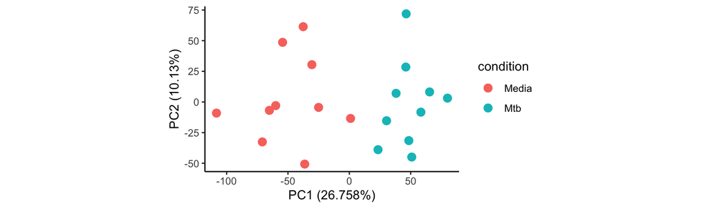

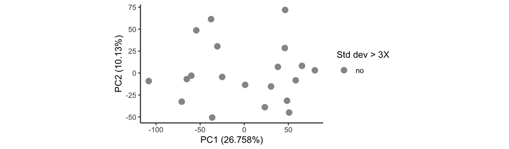

```r
plot_pca(dat, vars = c("condition", "outlier"))
```

Model fit metrics

```
Summary
```

```
  Best fit  Metric Total genes Mean delta Stdev delta
1       lm     AIC       10647  6.5535246    3.859962
2      lme     AIC        2772  4.2584460    4.588052
3       lm adj_Rsq        3583  3.8238324  118.478571
4      lme adj_Rsq        9836  0.9833688   28.855033
```

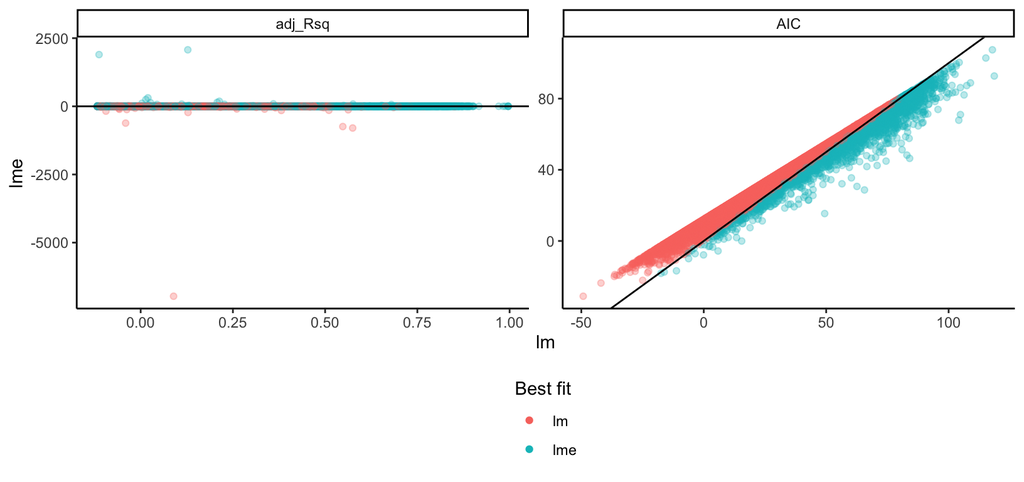

```r
plot_fit(model_result = fit_kimma,
         x="lm", y="lme", metrics = c("AIC","adj_Rsq"))
```

```
Summary
```

```
  Best fit  Metric Total genes Mean delta Stdev delta
1       lm     AIC       10647  6.5535246    3.859962
2      lme     AIC        2772  4.2584460    4.588052
3       lm adj_Rsq        3583  3.8238324  118.478571
4      lme adj_Rsq        9836  0.9833688   28.855033
```

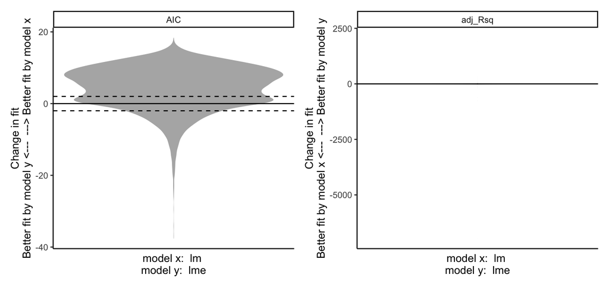

```r
plot_fit2(model_result = fit_kimma,
         x="lm", y="lme", metrics = c("AIC","adj_Rsq"))
```

Significant gene Venn

```
$venn
$venn$`0.05`
```

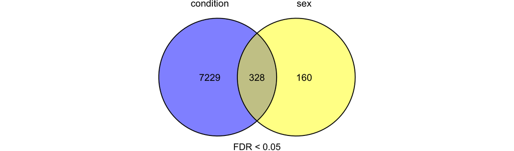

```r
plot_venn_genes(list("lme"=fit_kimma$lme), fdr.cutoff = 0.05)
```

Gene expression boxplots

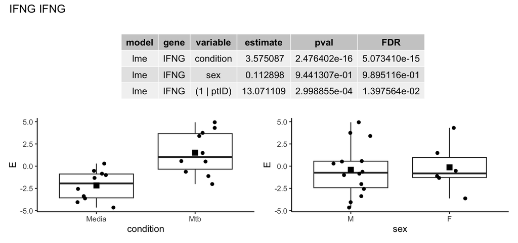

```r
plot_genes(dat, fdr = fit_kimma$lme, geneID = "hgnc_symbol",
           subset.genes = "IFNG", variables = c("condition","sex"))
```

STRING protein-protein interaction network

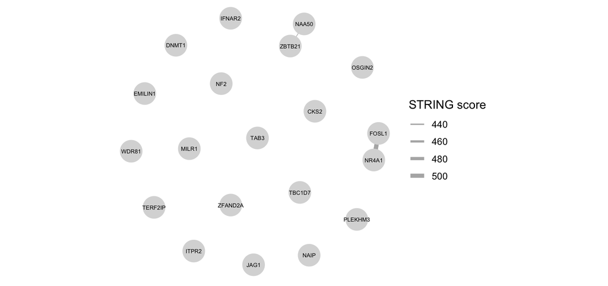

```r
#list top 20 most significant genes
genes.signif <- fit_kimma$lme %>%
  filter(variable == "condition") %>%
  slice_min(order_by = FDR, n = 20) %>%
  pull(gene)

#map genes to STRING database
map <- map_string(genes.signif)
#make plot
plot_string(map)
```

# *Navigation*

- [Workshop index](https://bigslu.github.io/workshops/2024_SEATRAC_series/homepage.html)